# NYCFlights: Arrival Delay Logictic Model

**KNIT YOUR DOCUMENT AS *HTML* AND SUBMIT IT AND THE `Rmd` file.**

## Rubric

Points (10)

- 1 Provided knitted documentas HTML or PDF
- *Logsitic and Inverse Logistic Transformation*
- 1 created logistic function and plotted it
- 1 created inv logistic function and plotted it
- *NYCFlights Model*
- 1 Clearly articulates the target/response value that is being modeled and specified a *Performance Metric* for evaluating the model
- 1 Suggested a Naive Model
- 1 Measured Performance of the Naive Model: Accuracy might be a good one
- 1 Specified response and plotted it or created a table for it
- 1 Fit model using `glm( family = binomial )` or similar
- 1 Evaluated model performance using *Performance Metric*
- 1 Answered questions regarding good model? Do and evaluators accepts that answer

Bonus: - 1 Refit model with reduced set of features according to the above

## Logsitic and Inverse Logistic Transformation

- Write an R function for the logistic function. The function should accept a `numeric` vector with values `[-Inf,Inf]` and produce a numeric vector in the the range `[0,1]`.
- Plot the logistic function from `[-10,10]`
- Write a R function for the inverse logistic function. The function should accept a `numeric` vector with values `[0,1]` and prodcuce a numeric vector in the range `[-Inf,Inf]`
- Plot the Inverse Logistic function from `[0,1]`

**Hint:** For plotting curves see `?graphics::curve` or `?ggplot2::stat_function`

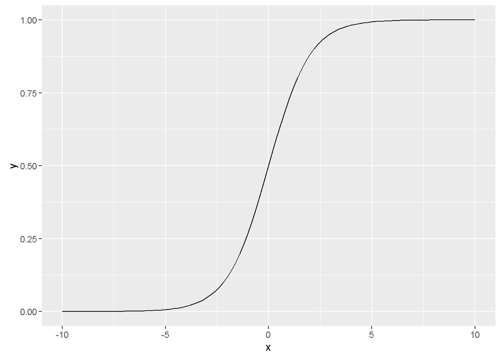

```r
logistic <- function(x) {
 # Your work here
  1/(1 + exp(-x))
}

ggplot( data=data.frame(x=c(-10,10)), aes(x)) + stat_function(fun=logistic)
```

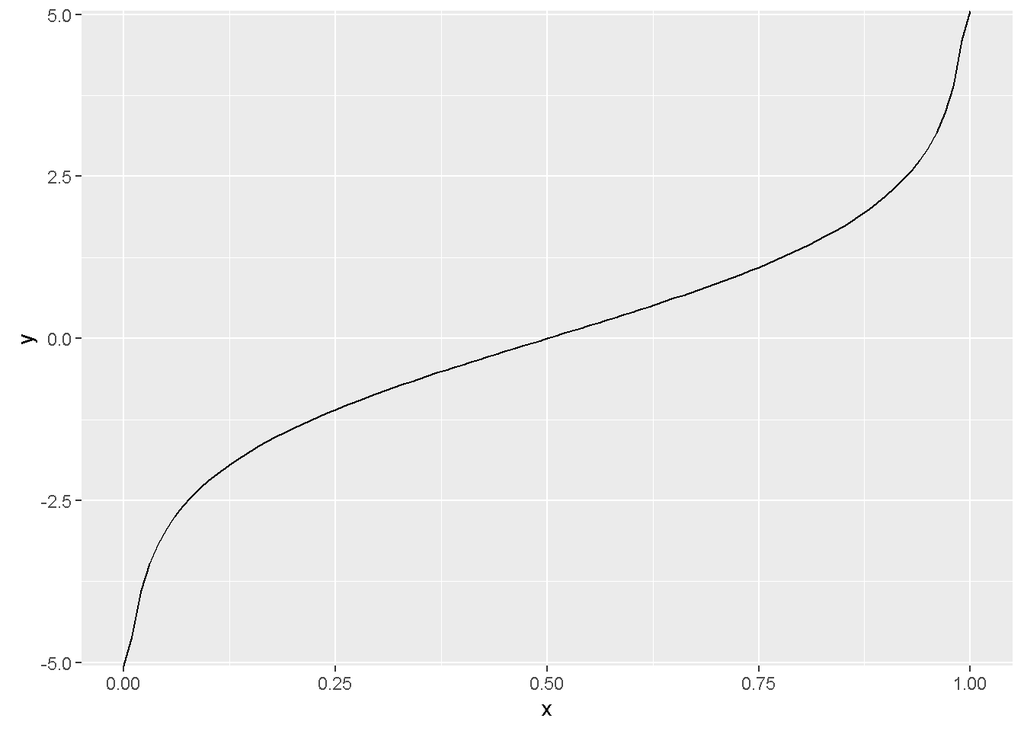

```r
logistic_inv <- function(y) {
  # Your work
  -log(1/y - 1)
}

ggplot( data=data.frame(x=c(0,1)), aes(x)) + stat_function(fun=logistic_inv)
```

# NYCFlights Model

## Step 1: Load Data

```r
#' Same as previous
YX <- readRDS( "nycflights_joined.rds")
```

## Step 2: Response

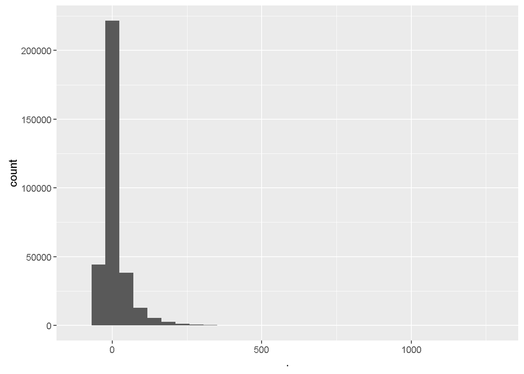

```r
library(ggplot2)

YX$arr_delay %>% qplot
```

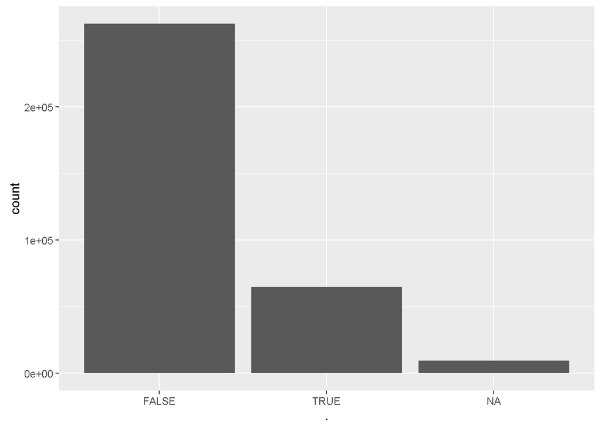

```r
#' Same as previous

YX <- YX[ , late := factor(arr_delay >= 22) ]

YX$late %>% qplot
```

```r
YX$late %>% table()
```

```
## .
##  FALSE   TRUE
## 262387  64959
```

```r
late_pct <- ( sum(YX$late == TRUE, na.rm=TRUE )/( YX$late %>% na.omit %>% length ) )
```

Flights are 19.8% late.

The naive model is assuming that all of the flights are on time. (Note: This is not a good assumption as we will learn in class.) The Naive model has an accuracy of 80.2%.

The model will be measured as a function of predicted probabilty of lateness vs actual lateness. This is the same as the accuracy.

## Step 3: Predictors

These were created for the model in the previous week’s exercise. That is not repeated here.

## Step 3: Train The Model

```r
yx <- copy(YX)
form <-
  late ~ dep_delay + month + air_time + distance + carrier + lat.dest + lon.dest

fit.glm <- glm( form, yx, family=binomial() )
# fit.glm <- lm( arr_delay ~ . , yx %>% sample_n(1e5) )
fit.step <- MASS::stepAIC(fit.glm, scope=list(upper=. ~ ., lower = . ~ 1 ) )
```

```
## Start:  AIC=118510.7
## late ~ dep_delay + month + air_time + distance + carrier + lat.dest +
##     lon.dest
```

```
##             Df Deviance    AIC
## <none>           118467 118511
## - lat.dest   1   118475 118517
## - lon.dest   1   118528 118570
## - month      1   118577 118619
## - carrier   15   120566 120580
## - distance   1   129884 129926
## - air_time   1   141570 141612
## - dep_delay  1   306589 306631
```

```r
summary(fit.step)
```

```
##
## Call:
## glm(formula = late ~ dep_delay + month + air_time + distance +
##     carrier + lat.dest + lon.dest, family = binomial(), data = yx)
##
## Deviance Residuals:
##     Min       1Q   Median       3Q      Max
## -3.0800  -0.2961  -0.1785  -0.0908   4.0242
##
## Coefficients:
##               Estimate Std. Error z value Pr(>|z|)
## (Intercept) -3.1444898  0.1845866 -17.035  < 2e-16 ***
## dep_delay    0.1250337  0.0005469 228.637  < 2e-16 ***
## month        0.0218182  0.0020738  10.521  < 2e-16 ***
## air_time     0.0902997  0.0006582 137.189  < 2e-16 ***
## distance    -0.0109933  0.0001114 -98.655  < 2e-16 ***
## carrierAA    0.0568430  0.0478227   1.189  0.23459
## carrierAS   -0.5235900  0.2237514  -2.340  0.01928 *
## carrierB6    0.5792632  0.0439841  13.170  < 2e-16 ***
## carrierDL    0.2724903  0.0446345   6.105 1.03e-09 ***
## carrierEV    0.4615568  0.0413064  11.174  < 2e-16 ***
## carrierF9    1.0704686  0.1327195   8.066 7.28e-16 ***
## carrierFL    1.2009043  0.0742375  16.177  < 2e-16 ***
## carrierHA    1.9375546  0.3184534   6.084 1.17e-09 ***
## carrierMQ    1.0779410  0.0449580  23.977  < 2e-16 ***
## carrierOO    0.9779684  0.9232209   1.059  0.28946
## carrierUA    0.0503117  0.0437212   1.151  0.24984
## carrierUS    0.9149785  0.0486115  18.822  < 2e-16 ***
## carrierVX   -0.2089353  0.0799078  -2.615  0.00893 **
## carrierWN   -0.3877707  0.0546161  -7.100 1.25e-12 ***
## carrierYV    0.7897193  0.1931674   4.088 4.35e-05 ***
## lat.dest    -0.0079906  0.0028069  -2.847  0.00442 **
## lon.dest     0.0293981  0.0037488   7.842 4.44e-15 ***
## ---
## Signif. codes:  0 '***' 0.001 '**' 0.01 '*' 0.05 '.' 0.1 ' ' 1
##
## (Dispersion parameter for binomial family taken to be 1)
##
##     Null deviance: 319231  on 319808  degrees of freedom
## Residual deviance: 118467  on 319787  degrees of freedom
##   (16967 observations deleted due to missingness)
## AIC: 118511
##
## Number of Fisher Scoring iterations: 7
```

```r
saveRDS(fit.step, file="fit.step.rds")
```

## Step 4: Evaluate Performance

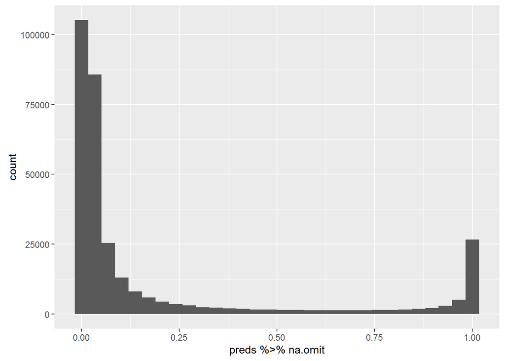

```r
preds <- predict( fit.step, yx, type="response")
qplot(preds %>% na.omit, bins=30 )
```

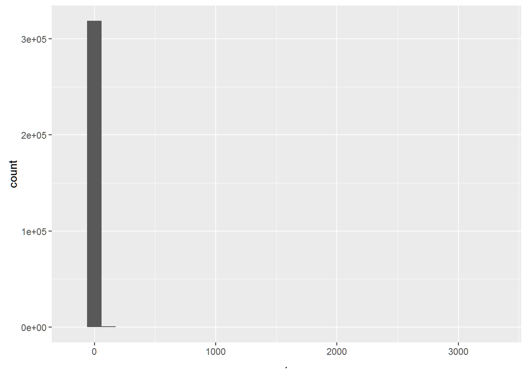

```r
fit.step$residuals %>% qplot()
```

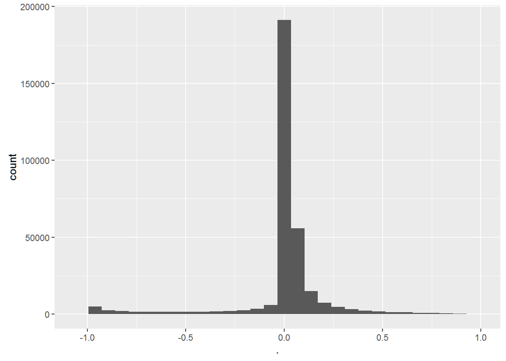

```r
errs <- (preds - (yx$late == "TRUE") )
(preds - (yx$late == "TRUE") ) %>% qplot( )
```

```r
mean( errs)
```

```
## [1] NA
```

## Step 5: Improve Performance

# Question:

# PART B:

Your model should be good at explaining tardiness. Now, assume that your job is to predict arrival delays a month in advance. You can no longer use all the features in your model. Retrain your model using only features that will be *known* only a month in advance of the departure time. Show all steps as above.